# Microbiome-Environment Spatial Analysis Pipeline

**A comprehensive workflow for modeling microbial diversity using real environmental data and spatial cross-validation**

## Overview

This analysis demonstrates a complete pipeline for modeling microbial diversity patterns across landscapes using real environmental data layers. The workflow incorporates:

### 🌍 **Real Environmental Data Integration**

- WorldClim climate layers (temperature, precipitation)
- SoilGrids soil properties (pH, organic carbon)
- Proper spatial resolution matching and resampling

### 🔬 **Realistic Microbiome Simulation**

- Environment-driven community composition
- Multinomial count data with realistic sequencing depths
- Phyloseq integration for standard microbiome workflows

### 📊 **Spatial Statistics**

- Moran’s I test for spatial autocorrelation in diversity
- Mantel test for distance-decay relationships
- Conditional spatial cross-validation implementation

### 🗺️ **Prediction and Visualization**

- Large-scale spatial prediction mapping
- Interactive leaflet visualizations
- Model validation against environmental drivers

## Technical Skills Demonstrated

- **R Programming**: Advanced data manipulation, statistical analysis, and visualization
- **Spatial Analysis**: Raster processing, coordinate systems, spatial statistics
- **Machine Learning**: XGBoost, cross-validation, model diagnostics
- **Microbiome Analytics**: Phyloseq, diversity metrics, community ecology
- **Data Visualization**: Static plots, interactive maps, diagnostic plots
- **Reproducible Research**: Structured workflow, documentation, version control ready

The analysis focuses on Spain, simulating microbiome data on Catalonia that responds realistically to environmental gradients to predict alpha diversity of the country.

## Setup and Dependencies

```r
# ===========================
# MICROBIOME + ENVIRONMENT PIPELINE (REAL ENV LAYERS + SOILGRIDS + SPATIAL CV)
# ===========================
library(phyloseq)
library(vegan)
library(tidyverse)
library(sf)
library(terra)
library(geodata)
library(xgboost)
library(caret)
library(leaflet)
library(leafem)
library(geodist)
library(rnaturalearth)
library(rnaturalearthhires)
library(spdep)
library(blockCV)
library(geosphere)
library(patchwork)

set.seed(42069)
```

## 1. Study Area and Sample Design

We generate random sampling locations across Catalonia, Spain to simulate a realistic field sampling campaign.

```r
# ===========================
# 1) Simulate Metadata (Cataluña)
# ===========================
n_samples <- 100
spain_states <- ne_states(country = "Spain", returnclass = "sf")
catalonia    <- spain_states[spain_states$woe_name == "Cataluña", ]

random_points <- st_sample(catalonia, size = n_samples)
metadata <- st_coordinates(random_points) %>% as.data.frame()
metadata$SampleID <- paste0("S", 1:n_samples)
colnames(metadata) <- c("Longitude", "Latitude", "SampleID")
rownames(metadata) <- metadata$SampleID

cat("Generated", n_samples, "sampling locations across Catalonia\n")
```

```
## Generated 100 sampling locations across Catalonia
```

## 2. Environmental Data Acquisition

We fetch real environmental data from two major global databases:

### 2.1 WorldClim Climate Data

- **BIO1**: Annual Mean Temperature (°C)
- **BIO12**: Annual Precipitation (mm)

### 2.2 SoilGrids Soil Properties

- **pH**: Soil pH (H2O) at 5-15cm depth
- **OC**: Organic Carbon Density at 5-15cm depth

```r
# ===========================
# 2) Fetch Real Env Data
# ===========================
# 2a) WorldClim (Temp & Precip)
worldclim <- geodata::worldclim_global(var = "bio", res = 5, path = "worldclim_data")
wc_layers <- worldclim[[c(1, 12)]] # BIO1 (== Temp) & BIO12 (== Precip)
names(wc_layers) <- c("Temp", "Precip")

# 2b) SoilGrids (pH & Organic Carbon)
sg_layers <- geodata::soil_world(var = c("phh2o","ocd"), path="soilgrids_data", depth = 15, res = 5) ### THIS PULLS THE SOILGRIDS RASTERS (organic carbon and pH)
sg_layers <- sg_layers[[c("phh2o_5-15cm", "ocd_5-15cm")]]
names(sg_layers) <- c("pH","OC")

# NOTE: for whatever reason, soil_world ignores res = 5, so i need to resample to match worldclim's and be able to merge. fine.
res(wc_layers)
```

```
## [1] 0.08333333 0.08333333
```

```r
res(sg_layers)
```

```
## [1] 0.008333333 0.008333333
```

```r
sg_resampled <- terra::resample(sg_layers, wc_layers, method = "bilinear")

# Combine all layers
env_layers <- c(wc_layers, sg_resampled)

# Extract for sample points
pts_vect  <- vect(st_as_sf(metadata, coords=c("Longitude","Latitude"), crs=4326))
env_data  <- terra::extract(env_layers, pts_vect)[,-1]
metadata  <- bind_cols(metadata, env_data)

# Remove samples with NA (probaly landed on marine areas where there's no soil ans such)
valid_rows <- complete.cases(metadata)
metadata   <- metadata[valid_rows, ]
pts_vect   <- pts_vect[valid_rows, ]
env_data   <- env_data[valid_rows, ]

# update n_samples
n_samples <- nrow(metadata)

cat("Successfully extracted environmental data for", n_samples, "samples\n")
```

```
## Successfully extracted environmental data for 95 samples
```

```r
cat("Environmental layers:", names(env_layers), "\n")
```

```
## Environmental layers: Temp Precip pH OC
```

## 3. Microbiome Data Simulation

We simulate realistic microbiome count data where community composition is driven by environmental gradients, specifically pH in this case.

```r
# ===========================
# 3) Simulate Microbiome Counts (driven by real env)
# ===========================
n_otus <- 1000

# base abundances
base_ab  <- rlnorm(n_otus, meanlog=4, sdlog=1)

# pick variable!
colnames(metadata)
```

```
## [1] "Longitude" "Latitude"  "SampleID"  "Temp"      "Precip"    "pH"
## [7] "OC"
```

```r
top_Var <- c("pH")
var_distro <- 0.4

# OTU responses
top_Var_effect  <- rnorm(n_otus,0,var_distro) # strong effect. to soften, 0.1 or less

# expected abundances
expected_abund <- t(sapply(1:n_samples, function(j){
  ba <- base_ab * exp(top_Var_effect     * metadata[[top_Var]][j])
  ba / sum(ba)
}))

colnames(expected_abund) <- paste0("OTU",1:n_otus)
rownames(expected_abund) <- metadata$SampleID

# simulate sequencing depths and counts
seq_depth <- rpois(n_samples, lambda=20000)
otu_mat   <- sapply(1:n_samples, function(i){
  rmultinom(1, size=seq_depth[i], prob=expected_abund[i,])
})
otu_mat   <- matrix(otu_mat, nrow=n_otus, dimnames=list(paste0("OTU",1:n_otus), metadata$SampleID))

head(otu_mat)
```

```
##      S1 S2 S3 S4 S5 S6 S7 S8 S10 S11 S12 S13 S14 S15 S17 S18 S19 S20 S21 S22
## OTU1  0  0  0  0  0  0  0  0   0   0   0   0   0   0   0   0   0   0   0   0
## OTU2  4  0  4  2  2  3  4  0   5   7   7   3   4   3   2   3   2   3   9   3
## OTU3  0  0  0  0  0  0  0  0   1   1   0   0   0   0   0   0   0   0   2   1
## OTU4  0  0  0  1  1  0  0  1   1   2   1   0   1   0   1   1   3   0   0   1
## OTU5 23  7 13 21 19 12 24 12  23  18  12   9   8   9  14  19  14   6  28  11
## OTU6  0  0  0  0  0  0  0  0   0   0   0   0   0   0   0   0   0   0   0   0
##      S23 S24 S25 S26 S27 S28 S29 S30 S31 S32 S33 S34 S37 S38 S39 S40 S41 S42
## OTU1   0   0   0   0   0   0   0   0   0   0   0   0   0   0   0   0   0   0
## OTU2   1   5   2   3   3   2   6   1   3   6   3   4   4   3   3   5   3   6
## OTU3   0   0   0   1   0   1   1   0   0   1   0   0   0   0   0   1   0   0
## OTU4   1   0   0   0   3   0   0   0   0   4   0   0   1   0   0   2   2   0
## OTU5  17   8  28  12  12   7  24  23  25  37  23  18  20  15  34  16  19  18
## OTU6   0   0   0   0   0   0   0   0   0   0   0   0   0   0   0   0   0   0
##      S43 S44 S45 S46 S47 S48 S49 S50 S51 S52 S53 S54 S55 S56 S57 S58 S59 S60
## OTU1   0   0   0   0   0   0   0   0   0   0   0   0   0   0   0   0   0   0
## OTU2   3   1   2  10   6   4   4   3   5   2   9   2   3   2   0   3   4   6
## OTU3   0   0   0   0   0   0   0   0   0   0   0   0   0   0   0   0   0   0
## OTU4   0   0   0   2   1   2   1   1   1   0   0   1   1   1   0   0   2   1
## OTU5  10  12  10  24  39  12  22  15   9  16  27  15   8  18  11  19  21  17
## OTU6   0   0   0   0   0   0   0   0   0   0   0   0   0   0   0   0   0   0
##      S61 S62 S63 S64 S65 S66 S67 S68 S69 S70 S71 S72 S73 S74 S75 S76 S78 S79
## OTU1   0   0   0   0   0   0   0   0   0   0   0   0   0   0   0   0   0   0
## OTU2   6   2   2   4   3   9   4   3   2   2   6   4   2   5   1   0   1   0
## OTU3   1   0   0   2   0   0   0   0   0   0   0   0   0   0   0   2   0   1
## OTU4   0   0   1   1   1   1   1   1   0   1   0   1   0   2   0   0   0   0
## OTU5  44   8   7  17  17  13  16  15   7   5   7  27  11   9  13  14   9  10
## OTU6   0   0   0   0   0   0   0   0   0   1   0   0   0   0   0   0   0   0
##      S80 S81 S82 S83 S84 S85 S86 S87 S88 S89 S90 S91 S92 S93 S94 S95 S96 S97
## OTU1   0   0   0   0   0   0   0   0   0   0   0   0   0   0   0   0   0   0
## OTU2   3   1   6   6   3   4   1   2  10   6   2   5   1   3   5   9   7   0
## OTU3   0   0   1   0   0   0   1   0   1   0   0   0   0   0   0   0   0   0
## OTU4   0   1   1   0   1   1   0   0   1   1   0   1   0   0   0   1   1   0
## OTU5  18  17  31  31   9  10  21  16  32  16   7  20  16  14  12  18   9  12
## OTU6   0   0   0   0   0   0   0   0   0   0   0   0   0   0   0   0   0   0
##      S98 S99 S100
## OTU1   0   0    0
## OTU2   2   2    6
## OTU3   0   0    1
## OTU4   0   2    2
## OTU5  19  18    8
## OTU6   0   0    0
```

```r
# MERGE METADATA AND MICROBIOME DATA TO CREATE THE PHYLOSEQ OBJECT
ps <- phyloseq(
  otu_table(otu_mat, taxa_are_rows = TRUE),
  sample_data(metadata)
)

cat("Created phyloseq object with", n_otus, "OTUs and", n_samples, "samples\n")
```

```
## Created phyloseq object with 1000 OTUs and 95 samples
```

```r
cat("Environmental driver selected as primary:", top_Var,"\n")
```

```
## Environmental driver selected as primary: pH
```

## 4. Alpha Diversity Calculation

We calculate Shannon and Simpson diversity indices for each sample.

```r
# ===========================
# 4) EStimate richness
# ===========================
div <- estimate_richness(ps, measures=c("Shannon","Simpson")) %>%
  rownames_to_column("SampleID")
div_data <- left_join(metadata, div, by="SampleID")

head(div_data)
```

```
##   Longitude Latitude SampleID      Temp Precip       pH       OC  Shannon
## 1 1.8962907 42.38789       S1  8.379167    928 6.789342 3.260978 3.667017
## 2 0.5996041 41.05549       S2 16.264334    497 7.771845 2.046177 3.171897
## 3 0.4799096 40.85040       S3 16.331125    514 7.680486 2.251981 3.212280
## 4 1.0441228 42.24232       S4 10.098042    809 7.311780 2.779608 3.389910
## 5 2.8603867 41.84928       S5 14.307167    719 6.975787 2.382004 3.545135
## 6 0.5510906 41.74432       S6 14.231209    415 7.851118 1.975895 3.115246
##     Simpson
## 1 0.9245032
## 2 0.8930600
## 3 0.8953338
## 4 0.9075939
## 5 0.9184515
## 6 0.8888374
```

```r
cat("Shannon diversity range:", round(range(div_data$Shannon, na.rm = TRUE), 2), "\n")
```

```
## Shannon diversity range: 3.07 4.09
```

```r
cat("Simpson diversity range:", round(range(div_data$Simpson, na.rm = TRUE), 3), "\n")
```

```
## Simpson diversity range: 0.886 0.947
```

## 5. Spatial Autocorrelation Analysis

Before modeling, we test for spatial autocorrelation in our diversity data using two complementary approaches:

### 5.1 Moran’s I Test

Tests for spatial autocorrelation in Shannon diversity values based on geographic proximity.

### 5.2 Mantel Test

Tests for correlation between community dissimilarity and geographic distance.

```r
# ===========================
# 5) Spatial Autocorrelation Tests
# ===========================
# MORAN (on Shannon's div)
coords     <- cbind(div_data$Longitude, div_data$Latitude)
nb         <- spdep::knn2nb(spdep::knearneigh(coords, k=5))
lw         <- spdep::nb2listw(nb, style="W")
mor_test   <- spdep::moran.test(div_data$Shannon, lw)
print(mor_test)
```

```
##
##  Moran I test under randomisation
##
## data:  div_data$Shannon
## weights: lw
##
## Moran I statistic standard deviate = 14.152, p-value < 2.2e-16
## alternative hypothesis: greater
## sample estimates:
## Moran I statistic       Expectation          Variance
##       0.832655856      -0.010638298       0.003550746
```

```r
# MANTEL
comm_dist <- phyloseq::distance(ps, method = "bray")
coords <- cbind(div_data$Longitude, div_data$Latitude)
geo_dist <- geosphere::distm(coords, fun = distHaversine) #unit is in meters
geo_dist <- as.dist(geo_dist)
mantel_test <- vegan::mantel(comm_dist, geo_dist, method = "pearson", permutations = 9999)
print(mantel_test)
```

```
##
## Mantel statistic based on Pearson's product-moment correlation
##
## Call:
## vegan::mantel(xdis = comm_dist, ydis = geo_dist, method = "pearson",      permutations = 9999)
##
## Mantel statistic r: 0.3437
##       Significance: 1e-04
##
## Upper quantiles of permutations (null model):
##    90%    95%  97.5%    99%
## 0.0451 0.0583 0.0706 0.0883
## Permutation: free
## Number of permutations: 9999
```

```
##
##   train test
## 1    75   20
## 2    77   18
## 3    77   18
## 4    75   20
## 5    76   19
```

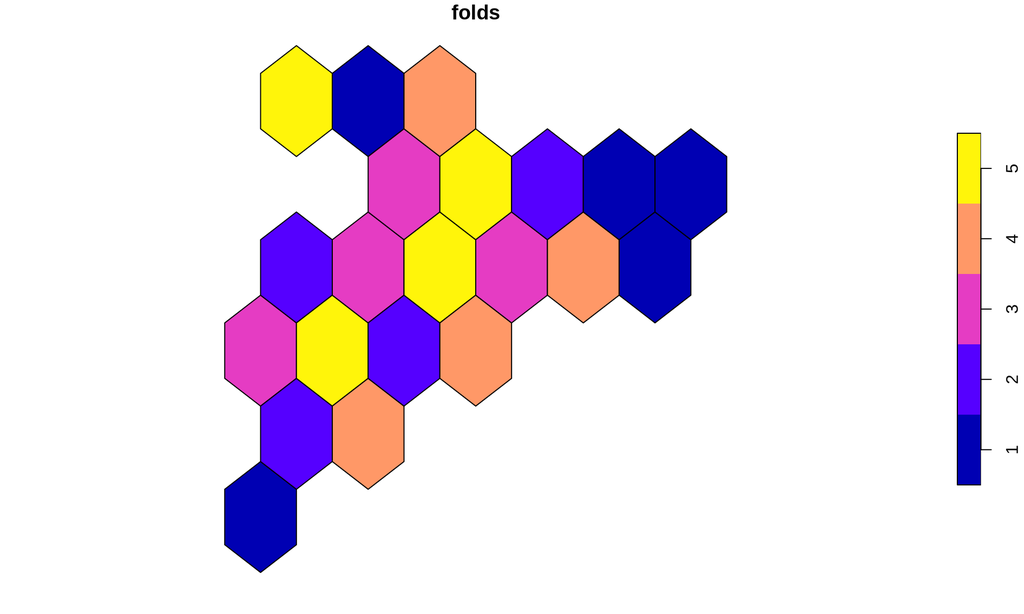

```
## Spatial autocorrelation detected: using spatial cross-validation
```

```r
# If significant autocorrelation by either moran or mantel, set up 5 spatial CV blocks
if (mor_test$p.value < 0.05 | mantel_test$signif < 0.05){

  AUTOCORR = TRUE # for later ;)

  sf_data <- st_as_sf(div_data, coords = c("Longitude", "Latitude"), crs = 4326)

png("spatial_blocks.png", width = 800, height = 800, res = 150)

blocks <- cv_spatial(
  x = sf_data,
  column = NULL,
  k = 5,
  size = 50000,   # block size in meters (50 km)
  selection = "random",
  seed = 420,
  progress = FALSE
)

dev.off()

plot(blocks)

  cat("Spatial autocorrelation detected: using spatial cross-validation\n")

} else{

  AUTOCORR = FALSE

  print("No spatial autocorrelation found.")

}
```

## 6. Machine Learning Model Development

We use XGBoost to predict Shannon diversity from environmental variables, employing spatial cross-validation if autocorrelation is detected.

### 6.1 Model Training and Cross-Validation

```r
# ===========================
# 4) XGBoost Model (Spatially Aware if Needed)
# ===========================
model_data <- div_data %>% drop_na()

# Check if we have enough data
if (nrow(model_data) < 10) {
  stop("Not enough valid data points for modeling. Check environmental data extraction.")
}

# Features and response
X <- as.matrix(model_data[, c("Temp", "Precip", "pH", "OC")])
y <- model_data$Shannon

dtrain <- xgb.DMatrix(data = X, label = y)

# define folds
if (AUTOCORR) {
  print("Created spatial folds.")
  folds <- split(seq_along(y), blocks$folds_ids)
} else {
  print("Created regular folds.")
  folds <- caret::createFolds(y, k = 5)
}
```

```
## [1] "Created spatial folds."
```

```r
# XGBoost Cross-Validation
params <- list(
  objective = "reg:squarederror",
  eval_metric = "rmse",
  eta = 0.05,
  max_depth = 3,
  subsample = 0.5,
  colsample_bytree = 0.5
)

set.seed(420)
cv <- xgb.cv(
  params = params,
  data = dtrain,
  folds = folds,  # spatial or random folds
  nrounds = 1000,
  early_stopping_rounds = 20,
  verbose = 0
)

cat("Cross-validation completed with", cv$best_iteration, "optimal rounds\n")
```

```
## Cross-validation completed with 397 optimal rounds
```

### 6.2 Model Diagnostics and Overfitting Assessment

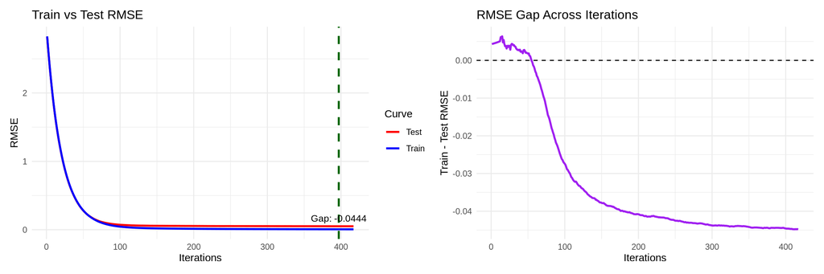

```r
# Overfitting Diagnostics
best_iter <- cv$best_iteration
eval_df <- cv$evaluation_log

# Plot 1: Train vs Test RMSE Curves
p1 <- ggplot(eval_df, aes(x = iter)) +
  geom_line(aes(y = test_rmse_mean, color = "Test"), size = 1) +
  geom_line(aes(y = train_rmse_mean, color = "Train"), size = 1) +
  geom_vline(xintercept = best_iter, color = "darkgreen", linetype = "dashed", size = 1) +
  annotate("text", x = best_iter,
           y = eval_df$test_rmse_mean[best_iter] + 0.02,
           label = paste0("Gap: ",
                          round(eval_df$train_rmse_mean[best_iter] -
                                eval_df$test_rmse_mean[best_iter], 4)),
           color = "black", vjust = -0.5, size = 3.5) +
  scale_color_manual(values = c("Test" = "red", "Train" = "blue")) +
  labs(y = "RMSE", x = "Iterations", color = "Curve") +
  theme_minimal() +
  ggtitle("Train vs Test RMSE")

# Plot 2: RMSE Gap
eval_df$rmse_gap <- eval_df$train_rmse_mean - eval_df$test_rmse_mean

p2 <- ggplot(eval_df, aes(x = iter, y = rmse_gap)) +
  geom_line(color = "purple", size = 1) +
  geom_hline(yintercept = 0, color = "black", linetype = "dashed") +
  labs(y = "Train - Test RMSE", x = "Iterations") +
  theme_minimal() +
  ggtitle("RMSE Gap Across Iterations")

combined_rmse <- p1 + p2 + plot_layout(ncol = 2)

print(combined_rmse)
```

```r
ggsave("xgboost_rmse_plots.png", combined_rmse, width = 12, height = 6, dpi = 300)

cat("Overfitting gap at best iteration:", round(eval_df$rmse_gap[best_iter], 4), "\n")
```

```
## Overfitting gap at best iteration: -0.0444
```

### 6.3 Final Model Training and Evaluation

```r
# ============================
# Train Final Model (using best nrounds)
# ============================
best_nrounds <- cv$best_iteration

set.seed(42069)
xgb_model <- xgboost(
  params = params,
  data = dtrain,
  nrounds = best_nrounds,
  verbose = 0
)

# Predictions & Evaluation (Train-Test Split) /random split only for evaluation metrics (not used for CV)
set.seed(420)
train_idx <- caret::createDataPartition(y, p = 0.7, list = FALSE)
X_test  <- X[-train_idx, ]
y_test  <- y[-train_idx]

pred <- predict(xgb_model, newdata = X_test)
correlation <- cor(y_test, pred)
cat("Model performance (Shannon ~ predicted):", round(correlation, 6), "\n")
```

```
## Model performance (Shannon ~ predicted): 0.999793
```

```r
# Variable Importance
importance <- xgb.importance(model = xgb_model)
par(mfrow = c(1, 1))
print(importance)
```

```
##    Feature       Gain     Cover Frequency
##     <char>      <num>     <num>     <num>
## 1:      pH 0.56687474 0.2908610 0.2565194
## 2:  Precip 0.22469984 0.2610828 0.2687600
## 3:      OC 0.16904417 0.2422349 0.2187334
## 4:    Temp 0.03938125 0.2058213 0.2559872
```

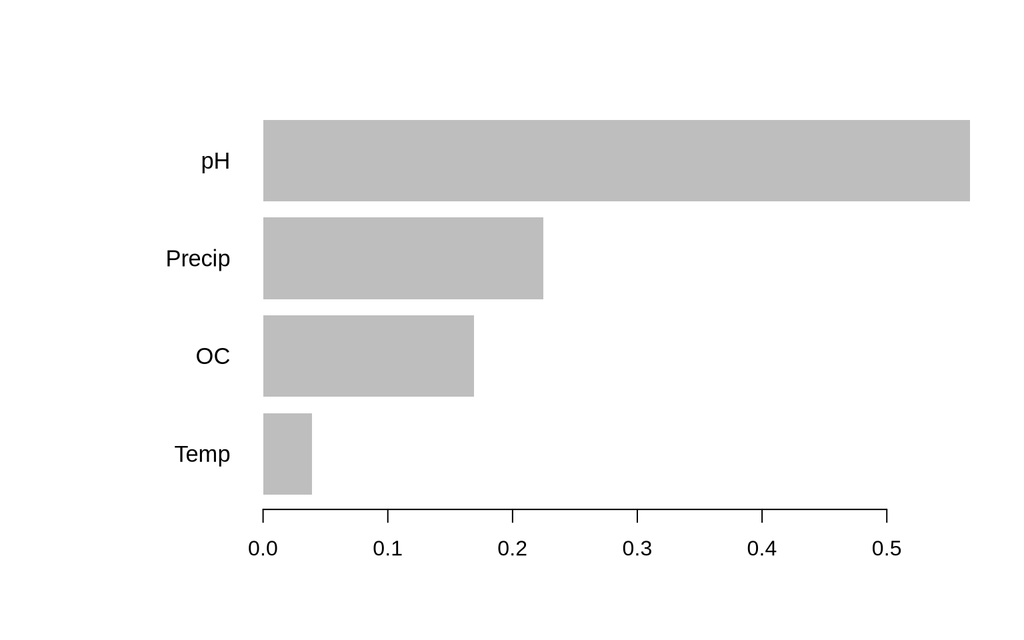

```r
xgb.plot.importance(importance)
```

## 7. Spatial Prediction and Mapping

We apply our trained model to predict Shannon diversity across the entire Spanish landscape.

```r
# ===========================
# 6) Predict Over Spain Raster
# ===========================
# prepare raster, aggregate for speed
spain_sf   <- ne_countries(country="Spain", returnclass="sf")
env_crop   <- crop(env_layers, ext(spain_sf)) %>% mask(vect(spain_sf))
env_agg    <- aggregate(env_crop, fact=2, fun=mean, na.rm=TRUE)

# predict function
pred_fun <- function(model, newdata){
  mat <- as.matrix(data.frame(Temp=newdata[,1],
                              Precip=newdata[,2],
                              pH=newdata[,3],
                              OC=newdata[,4]))
  predict(model, mat)
}

# Pedict over raster using the trained XGBoost model
predicted_map <- terra::predict(
  env_agg, xgb_model,
  fun = pred_fun,
  na.rm = TRUE
)

# Set layer name
names(predicted_map) <- "Shannon_Predicted"

cat("Successfully generated predictions across Spain\n")
```

```
## Successfully generated predictions across Spain
```

### 7.1 Model Validation: Prediction vs. Environmental Driver

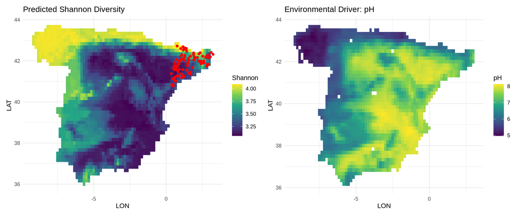

```r
## compare to variable used to create microbiome data. should be highly correlated!
spain_map <- crop(env_layers[[top_Var]], predicted_map)
spain_map <- resample(spain_map, predicted_map, method = "bilinear")
spain_map <- mask(spain_map, predicted_map)

# Convert rasters to data frames for ggplot
pred_df <- as.data.frame(predicted_map, xy = TRUE)
colnames(pred_df) <- c("LON", "LAT", "Shannon")

spain_df <- as.data.frame(spain_map, xy = TRUE)
colnames(spain_df) <- c("LON", "LAT", "Var")

# Predicted Shannon Diversity
p1 <- ggplot() +
  geom_raster(data = pred_df, aes(x = LON, y = LAT, fill = Shannon)) +
  scale_fill_viridis_c(option = "viridis", name = "Shannon") +
  geom_point(data = div_data, aes(x = Longitude, y = Latitude),
             color = "red", size = 1.5) +
  theme_minimal() +
  ggtitle("Predicted Shannon Diversity")

# Environmental Driver (Top Variable)
p2 <- ggplot() +
  geom_raster(data = spain_df, aes(x = LON, y = LAT, fill = Var)) +
  scale_fill_viridis_c(option = "viridis", name = top_Var) +
  theme_minimal() +
  ggtitle(paste("Environmental Driver:", top_Var))


combined_plot <- p1 + p2 + plot_layout(ncol = 2)

ggsave("diversity_environmental_driver.png", combined_plot,
       width = 14, height = 6, dpi = 300)

print(combined_plot)
```

```r
cat("Validation: Comparing predictions to", top_Var, "(the primary environmental driver). Should be highly correlated! \n")
```

```
## Validation: Comparing predictions to pH (the primary environmental driver). Should be highly correlated!
```

## 8. Interactive Visualization

```r
# ===========================
# 7) Interactive Map & Summary
# ===========================
# leaflet
pal <- colorNumeric(terrain.colors(50), values(predicted_map), na.color="transparent")
leaflet() %>%
  addTiles() %>%
  addRasterImage(predicted_map, colors=pal, opacity=0.7, group="Predicted Shannon") %>%
  addCircleMarkers(data=st_as_sf(div_data, coords=c("Longitude","Latitude"),crs=4326),
                   color="red", radius=5,
                   popup=~paste0("Samp:", SampleID,
                                 "<br>Shannon:",round(Shannon,2),
                                 "<br>Temp:",round(Temp,1),
                                 "<br>Precip:",round(Precip,0),
                                 "<br>pH:",round(pH,2),
                                 "<br>OC:",round(OC,1)),
                   group="Samples") %>%
  addLegend(pal=pal, values=values(predicted_map), title="Predicted Shannon", position="bottomright")
```

[interactive chart not shown]